# Effects on the Treated and Natural Effects

Lecture 6 vignette

Author

Causal Inference — STATS 420

Average effects can conceal important causal structure. This vignette studies ways to use *counterfactuals* to ask more specific, granular questions:

1. change the **target population**, from everyone to those who were treated;
2. decompose a treatment effect into pathways operating directly and through a mediator.

In both examples, the SCM lets us calculate the counterfactual quantities directly. We then discard the latent variables and recover the same quantities from the observed distribution using the identification formulas from the lecture.

# 1 Effect on the treated

Let $Z=1$ denote late-stage cancer, $X=1$ chemotherapy, and $Y=1$ survival. Consider the Markovian SCM

$$\begin{align}
Z &\gets \operatorname{Bern}(0.30),\\
X &\gets \operatorname{Bern}(0.1+0.6Z),\\
Y &\gets \operatorname{Bern}\!\left(
0.8-0.3Z+0.2XZ-0.1X(1-Z)
\right).
\end{align}$$

The treatment effect is heterogeneous:

| Disease stage | Without chemotherapy | With chemotherapy | Causal effect |
| --- | --- | --- | --- |
| Early, $Z=0$ | 80% | 70% | −10 pp |
| Late, $Z=1$ | 50% | 70% | +20 pp |

Chemotherapy is harmful for early-stage patients but helpful for late-stage patients. Moreover, late-stage patients receive it much more often: $P(X=1\mid Z=0)=0.10$ and $P(X=1\mid Z=1)=0.70$.

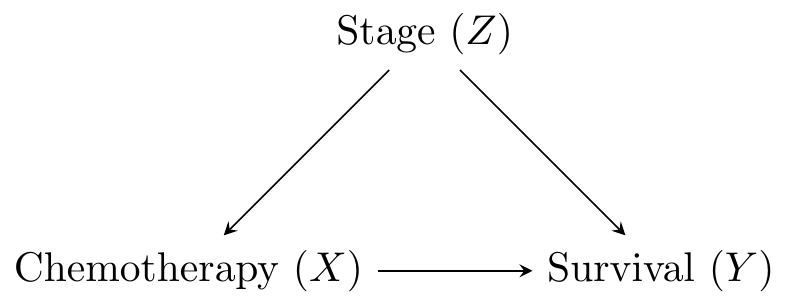

## 1.1 Generating observational and counterfactual data

We generate the data from the SCM:

```r
n <- 500000

ett_dat <- data.table(
  Z = rbinom(n, size = 1, prob = 0.30)
)

ett_dat[, X := rbinom(.N, size = 1, prob = 0.1 + 0.6 * Z)]

p_survival <- function(x, z) {
  0.8 - 0.3 * z + 0.2 * x * z - 0.1 * x * (1 - z)
}

U_Y <- runif(n)
ett_dat[, Y0 := as.integer(U_Y < p_survival(0, Z))]
ett_dat[, Y1 := as.integer(U_Y < p_survival(1, Z))]
ett_dat[, Y := fifelse(X == 1, Y1, Y0)]

ett_dat[1:6, .(Z, X, Y)]
```

| Z | X | Y |
| --- | --- | --- |
| 1 | 1 | 1 |
| 0 | 0 | 1 |
| 0 | 0 | 1 |
| 0 | 0 | 1 |
| 0 | 0 | 1 |
| 1 | 1 | 1 |

The observed outcome obeys consistency: $Y=Y_X$. The columns `Y0` and `Y1` are available only because we generated the complete SCM; an observational dataset would retain only $(Z,X,Y)$.

## 1.2 TV, ATE, and ETT

Three superficially similar contrasts answer different questions:

$$\begin{align}
\operatorname{TV}
&=\mathbb{E}[Y\mid X=1]-\mathbb{E}[Y\mid X=0],\\
\operatorname{ATE}
&=\mathbb{E}[Y_{x_1}-Y_{x_0}],\\
\operatorname{ETT}
&=\mathbb{E}[Y_{x_1}-Y_{x_0}\mid X=1].
\end{align}$$

TV compares different observed groups. ATE treats the full population as the target. ETT retains only the population that actually selected into treatment.

Because $Z$ is sufficient for adjustment, the counterfactual distribution conditional on observed treatment is identified by

$$\begin{align}
\mathbb{E}[Y_x\mid X=x']
&=\sum_z \mathbb{E}[Y\mid X=x,Z=z]P(Z=z\mid X=x').
\end{align}$$

The ETT therefore weights stage-specific causal effects by the stage distribution among treated patients:

$$\begin{align}
\operatorname{ETT}
&=\sum_z
\left\{
\mathbb{E}[Y\mid X=1,Z=z]
-\mathbb{E}[Y\mid X=0,Z=z]
\right\}P(Z=z\mid X=1).
\end{align}$$

```r
# Oracle quantities computed using both potential outcomes.
ate_oracle <- ett_dat[, mean(Y1 - Y0)]
ett_oracle <- ett_dat[X == 1, mean(Y1 - Y0)]

# Quantities computed after retaining only the observed variables.
tv_obs <- ett_dat[, mean(Y[X == 1]) - mean(Y[X == 0])]

stage_effect <- sapply(0:1, function(z) {
  ett_dat[Z == z & X == 1, mean(Y)] -
    ett_dat[Z == z & X == 0, mean(Y)]
})

pz <- sapply(0:1, function(z) ett_dat[, mean(Z == z)])
pz_treated <- sapply(0:1, function(z) ett_dat[X == 1, mean(Z == z)])

ate_identified <- sum(stage_effect * pz)
ett_identified <- sum(stage_effect * pz_treated)

# Exact values implied by the mechanisms.
p_treated <- 0.7 * 0.10 + 0.3 * 0.70
p_late_treated <- 0.3 * 0.70 / p_treated
p_late_untreated <- 0.3 * 0.30 / (1 - p_treated)

tv_exact <- 0.70 - ((1 - p_late_untreated) * 0.80 + p_late_untreated * 0.50)
ate_exact <- 0.7 * (-0.10) + 0.3 * 0.20
ett_exact <- (1 - p_late_treated) * (-0.10) + p_late_treated * 0.20

ett_results <- data.frame(
  Quantity = c("TV", "ATE", "ETT"),
  `Exact value` = pct(c(tv_exact, ate_exact, ett_exact)),
  `SCM oracle` = c("—", pct(ate_oracle), pct(ett_oracle)),
  `Observed-data calculation` = pct(c(tv_obs, ate_identified, ett_identified)),
  check.names = FALSE
)
```

Association and causal effects in the chemotherapy example.

| Quantity | Exact value | SCM oracle | Observed-data calculation |
| --- | --- | --- | --- |
| TV | -6.25% | — | -6.29% |
| ATE | -1.00% | -0.94% | -1.11% |
| ETT | 12.50% | 12.51% | 12.33% |

The treated group is 75% late-stage. Consequently, chemotherapy has a positive ETT even though its population-average effect is slightly negative. TV is also negative, but for a different reason: it compares treated and untreated patients rather than comparing treatment states for the same target population.

**NoteQuestions**

1. How can ETT be positive while ATE is negative?
2. Why does the observed TV fail to reveal the positive effect among treated patients?
3. Which distribution changes when we move from ATE to ETT?

# 2 Natural direct and indirect effects

Let $X=1$ denote semaglutide use, $W=1$ successful weight loss, and $Y=1$ a normal HbA1c level. Consider the Markovian SCM

$$\begin{align}
X &\gets \operatorname{Bern}(0.50),\\
W &\gets \operatorname{Bern}(0.1+0.2X),\\
Y &\gets \operatorname{Bern}(0.2+0.1W+0.05X).
\end{align}$$

Semaglutide can improve HbA1c directly and indirectly by making weight loss more likely.

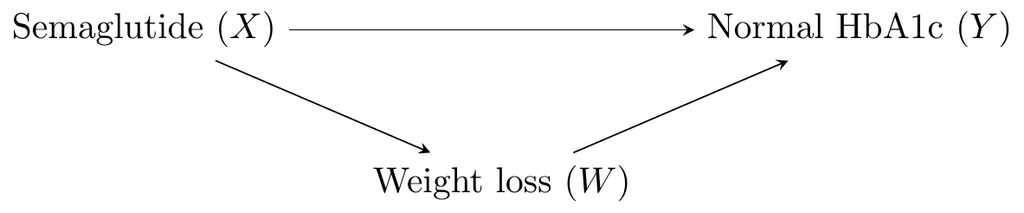

## 2.1 Generating the nested counterfactuals

We generate the data from the SCM, with the different potential outcomes for $W$ and $Y$.

```r
nde_dat <- data.table(
  X = rbinom(n, size = 1, prob = 0.50),
  W0 = rbinom(n, size = 1, prob = 0.10),
  W1 = rbinom(n, size = 1, prob = 0.30)
)

nde_dat[, W := fifelse(X == 1, W1, W0)]

make_y <- function(x, w) {
  rbinom(length(w), size = 1, prob = 0.2 + 0.1 * w + 0.05 * x)
}

nde_dat[, Y0W0 := make_y(0, W0)]
nde_dat[, Y1W0 := make_y(1, W0)]
nde_dat[, Y1W1 := make_y(1, W1)]
nde_dat[, Y := fifelse(X == 1, Y1W1, Y0W0)]

nde_dat[1:6, .(X, W, Y)]
```

| X | W | Y |
| --- | --- | --- |
| 1 | 1 | 0 |
| 0 | 0 | 1 |
| 0 | 0 | 0 |
| 0 | 0 | 1 |
| 0 | 0 | 0 |
| 0 | 0 | 0 |

The nested outcome $Y_{1,W_0}$ asks what would happen under treatment while setting each person’s mediator to the value it would naturally have taken without treatment.

## 2.2 Decomposing the total effect

For $x_0, x_1$, define

$$\begin{align}
\operatorname{ATE}
&=\mathbb{E}[Y_{x_1,W_{x_1}}]-\mathbb{E}[Y_{x_0,W_{x_0}}],\\
\operatorname{NDE}
&=\mathbb{E}[Y_{x_1,W_{x_0}}]-\mathbb{E}[Y_{x_0,W_{x_0}}],\\
\operatorname{NIE}_{\mathrm{rev}}
&=\mathbb{E}[Y_{x_1,W_{x_0}}]-\mathbb{E}[Y_{x_1,W_{x_1}}].
\end{align}$$

The NIE is deliberately written in the **reverse transition** used in this lecture: it moves the mediator from its treated natural value, $W_1$, back to its untreated natural value, $W_0$, while holding treatment fixed at $X=1$. With this direction,

$$\begin{align}
\operatorname{ATE}
&=\operatorname{NDE}-\operatorname{NIE}_{\mathrm{rev}}.
\end{align}$$

## 2.3 Identification from observed data

Under the independent-$U$ assumptions encoded by the Markovian graph, the nested counterfactual mean is identified by

$$\begin{align}
\mathbb{E}[Y_{x',W_x}]
&=\sum_w \mathbb{E}[Y\mid X=x',W=w]P(W=w\mid X=x).
\end{align}$$

The outcome regression is evaluated at $x'$, while the mediator distribution is taken from treatment level $x$. This deliberate mixing of two observational pieces reconstructs the nested counterfactual mean.

```r
# Oracle quantities from the complete SCM.
ate_oracle_nde <- nde_dat[, mean(Y1W1 - Y0W0)]
nde_oracle <- nde_dat[, mean(Y1W0 - Y0W0)]
nie_rev_oracle <- nde_dat[, mean(Y1W0 - Y1W1)]

# Identification functional computed from observed (X,W,Y) only.
nested_mean <- function(dat, x_prime, x) {
  sum(sapply(0:1, function(w) {
    dat[X == x_prime & W == w, mean(Y)] *
      dat[X == x, mean(W == w)]
  }))
}

mu_0w0 <- nested_mean(nde_dat, x_prime = 0, x = 0)
mu_1w0 <- nested_mean(nde_dat, x_prime = 1, x = 0)
mu_1w1 <- nested_mean(nde_dat, x_prime = 1, x = 1)

ate_identified_nde <- mu_1w1 - mu_0w0
nde_identified <- mu_1w0 - mu_0w0
nie_rev_identified <- mu_1w0 - mu_1w1

nde_results <- data.frame(
  Effect = c("ATE", "NDE", "NIE (reverse transition)"),
  Interpretation = c(
    "Overall treatment effect",
    "Direct effect with mediator held at its untreated natural value",
    "Move mediator from its treated value back to its untreated value"
  ),
  `Exact value` = pct(c(0.07, 0.05, -0.02)),
  `SCM oracle` = pct(c(ate_oracle_nde, nde_oracle, nie_rev_oracle)),
  `Observed-data identification` = pct(c(
    ate_identified_nde,
    nde_identified,
    nie_rev_identified
  )),
  check.names = FALSE
)
```

Total, natural direct, and reverse natural indirect effects.

| Effect | Interpretation | Exact value | SCM oracle | Observed-data identification |
| --- | --- | --- | --- | --- |
| ATE | Overall treatment effect | 7.00% | 7.08% | 7.21% |
| NDE | Direct effect with mediator held at its untreated natural value | 5.00% | 4.94% | 5.16% |
| NIE (reverse transition) | Move mediator from its treated value back to its untreated value | -2.00% | -2.13% | -2.05% |

Here, $7\text{ pp}=5\text{ pp}-(-2\text{ pp})$. The negative reverse NIE is beneficial in the forward causal direction: moving weight loss backward from $W_1$ to $W_0$ removes 2 percentage points of benefit. Equivalently, allowing the mediator to move forward from $W_0$ to $W_1$ contributes **+2 percentage points** to normal HbA1c.

The decomposition also holds unit by unit in this SCM:

$$\begin{align}
Y_{1,W_1}-Y_{0,W_0}
&=\left(Y_{1,W_0}-Y_{0,W_0}\right)
-\left(Y_{1,W_0}-Y_{1,W_1}\right).
\end{align}$$

```r
unit_ate <- nde_dat$Y1W1 - nde_dat$Y0W0
unit_decomposition <-
  (nde_dat$Y1W0 - nde_dat$Y0W0) -
  (nde_dat$Y1W0 - nde_dat$Y1W1)

all(unit_ate == unit_decomposition)
```

```
[1] TRUE
```

**NoteQuestions**

1. Why is the reverse NIE negative even though weight loss is beneficial?
2. Which mediator distribution is used to identify the NDE?
3. What would fail if $W$ and $Y$ had an unobserved common cause?

# 3 Takeaways

| Quantity | Target or pathway | Interpretation |
| --- | --- | --- |
| TV | Observed treated versus untreated groups | Association; generally not a causal effect |
| ATE | Entire population | Effect of treating everyone rather than nobody |
| ETT | Those who were actually treated | Treatment effect in the treated population |
| NDE | Direct pathway | Change treatment while retaining the untreated natural mediator |
| Reverse NIE | Mediated pathway, traversed backward | Remove the treatment-induced mediator change while treatment remains on |

Changing the target population explains the difference between ATE and ETT. Changing which mechanisms are allowed to respond explains the distinction between total, direct, and indirect effects.